# STAT 5533 Project Draft

Sitharama Bhargav, Anish Paudyal, Mason Robinson

2025-04-26

## 1. Introduction

### 1.1 Motivation

This project investigates how socioeconomic, demographic, and behavioral factors predict student academic performance. Educational data mining provides valuable insights for developing early intervention strategies, optimizing resource allocation, and improving educational outcomes. By identifying key predictors of student success, educators can implement targeted support systems to enhance learning experiences and reduce failure rates in secondary education. Our comparative analysis of machine learning techniques also contributes methodologically to the growing field of educational analytics.

### 1.2 Questions to be Answered

We want to explore three questions regarding this data:

1. Can we predict a student’s final grade (G3) based on the existing predictors?
2. Does feature selection improve predictive accuracy?
3. How does dimensionality reduction affect predictive performance?

### 1.3 Description of the Data

The dataset consists of 1044 students from two Portuguese secondary schools and includes 33 variables (30 predictors, 3 response variables: G1, G2, G3). These records combine mathematics (395 students) and Portuguese language (649 students) courses. Grades range from 0 to 20, with G3 representing final performance. Key predictors include demographic factors (age, sex), family characteristics (parental education, family size), academic variables (study time, absences), and lifestyle factors (alcohol consumption, extracurricular activities). This comprehensive set of variables enables exploration of multiple dimensions influencing student achievement.

## 2. Methodology

### 2.1 Data Processing

We first import both student .csv files, `student-mat.csv` and `student-por.csv`, respectively, for a combined total of 1044 observations. A quick overview of the data shows that both sets of students have a relatively normal distribution with respect to G3 with the exception of grades of zero. When the datasets are combined, this new total dataset also features a nearly normal distribution with respect to G3 in Figures 1-3. Removing the observations with the zeros for grades in G3 reveals this normal distribution, shown below in Figure 4.

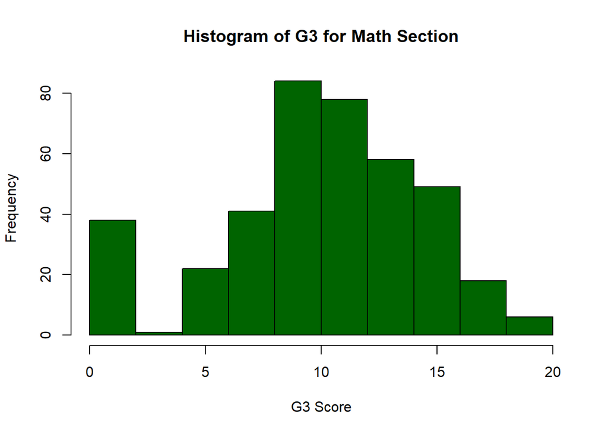

Histogram of G3 grade for the math section, zeros included.

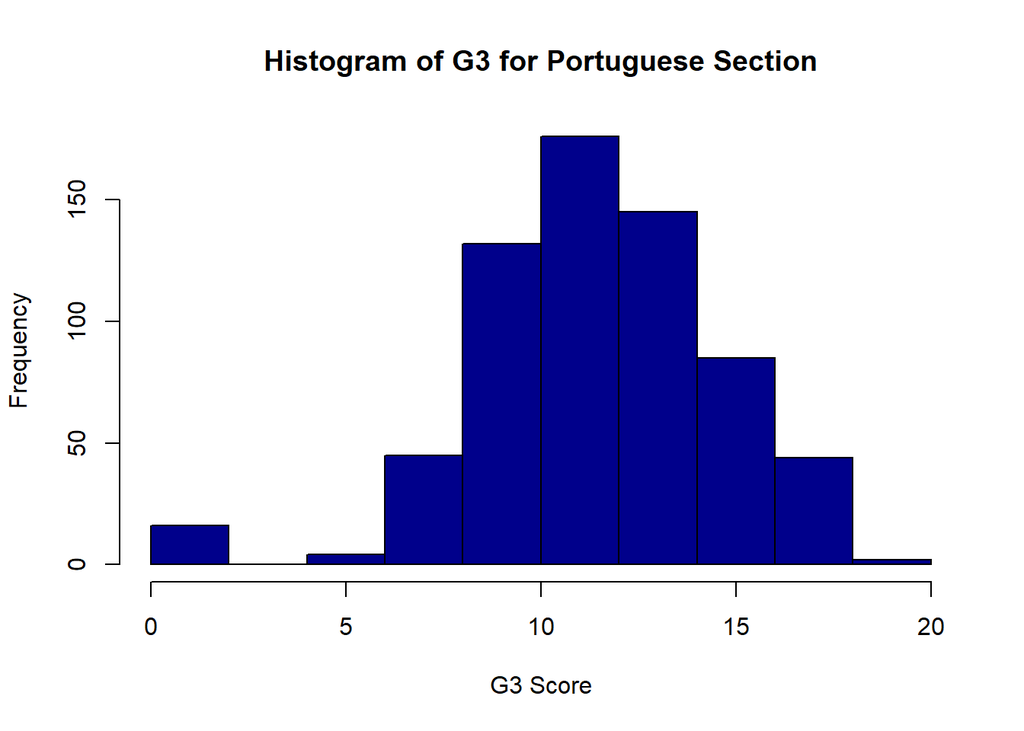

Histogram of G3 grade for the Portuguese section, zeros included.

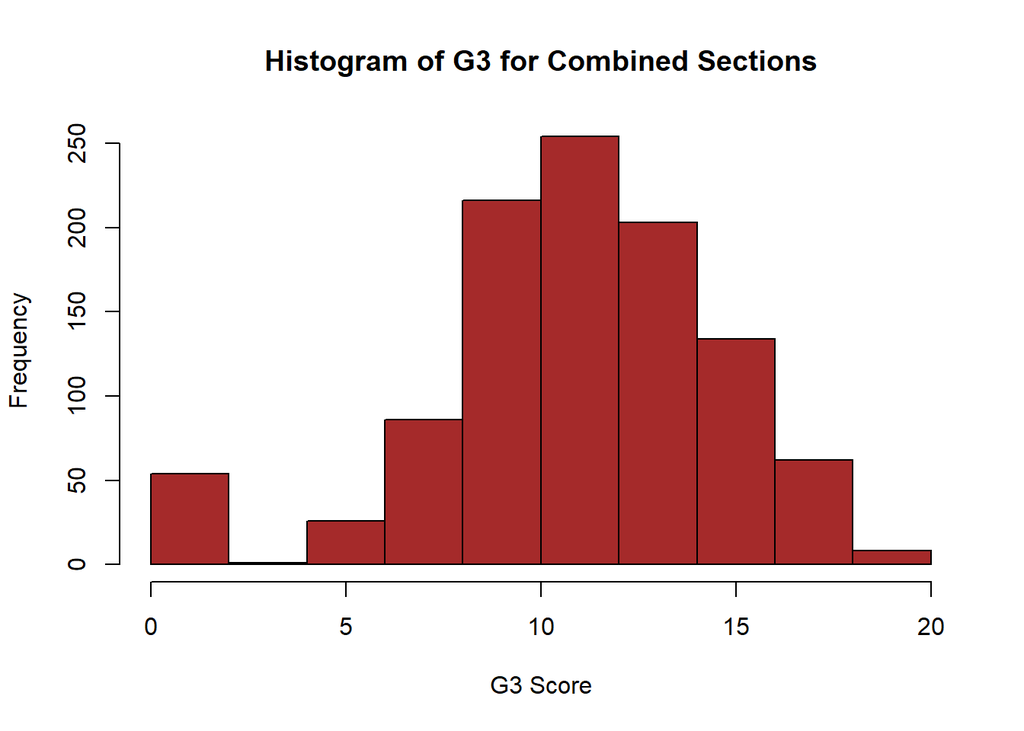

Histogram of G3 grade for Math and Portuguese combined, zeros included.

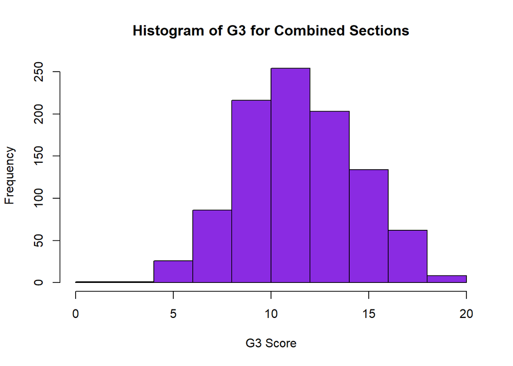

Histogram of G3 grade for Math and Portuguese combined, zeros excluded.

From analyzing the data, we can see that none of the students who received zeros in G3 had any absences. Given this information, it can be inferred, then, that zeros in G3 don’t represent failing every assignment–instead, it means that those students didn’t finish the year for one reason or another. Likewise, if we want to analyze which factors are most pertinent in predicting final grade scores, the obviously most important factors are what the students made on previous exams: usually students tend to score similar grades on concurrent exams. By this logic, there might be some factors that might be “drowned out” by these two factors. By removing them, our predictive models might change. Thus, we essentially have four descriptively named datasets: `data`, which contains all of the observations and factors; `data2`, which contains all of the factors, but the observations with the zeros in G3 were removed; `data3`, which contains all of the observations, but factors G1 and G2 were removed; and finally `data4`, which contains all observations except for observations with zeros in G3, and contains all factors but G1 and G2. Using the following techniques, we explore how the mean square error (MSE) changes based on each dataset, and which techniques worked best on each dataset.

### 2.2 Analysis Techniques

We used seven different regression techniques to analyze this data: multiple linear regression (MLR), lasso regression, ridge regression, principal component regression (PCR), support vector regression (SVR) with linear, polynomial, and radial kernels, Bayesian Additive Regression Trees (BART), and tree-based regression. We also randomly select 80% of each dataset for four different training sets (each for their respective dataset) and the remaining observations are reserved for testing sets.

#### 2.2.1 Multiple Linear Regression

```r
fit_mlr_1 <- lm(G3 ~ ., data = train_reg_1)
fit_mlr_2 <- lm(G3 ~ ., data = train_reg_2)
fit_mlr_3 <- lm(G3 ~ ., data = train_reg_3)
fit_mlr_4 <- lm(G3 ~ ., data = train_reg_4)
```

We then use the `predict()` function to make predictions using the model we created using the training data on the test data:

```r
pred_mlr_1 <- predict(fit_mlr_1, test_reg_1)
pred_mlr_2 <- predict(fit_mlr_2, test_reg_2)
pred_mlr_3 <- predict(fit_mlr_3, test_reg_3)
pred_mlr_4 <- predict(fit_mlr_4, test_reg_4)
```

Finally, we compare how the predictions do on the test set’s G3 data:

```r
mse_mlr_1 <- mean((test_reg_1$G3 - pred_mlr_1)^2)
mse_mlr_2 <- mean((test_reg_2$G3 - pred_mlr_2)^2)
mse_mlr_3 <- mean((test_reg_3$G3 - pred_mlr_3)^2)
mse_mlr_4 <- mean((test_reg_4$G3 - pred_mlr_4)^2)
```

#### 2.2.2 Lasso Regression

For lasso regression, in order for the `glmnet()` function to work correctly, we converted the training and test datasets into matrices that the `glmnet()` function can read using the function `model.matrix()` for the predictors, and we set aside the response training variable, like so:

```r
# data training data
x1_train <- model.matrix(G3 ~ ., train_reg_1)[, -1]
y1_train <- train_reg_1$G3

# data test data
x1_test <- model.matrix(G3 ~ ., test_reg_1)[, -1]

# data2
x2_train <- model.matrix(G3 ~ ., train_reg_2)[, -1]
y2_train <- train_reg_2$G3

# data2 test data
x2_test <- model.matrix(G3 ~ ., test_reg_2)[, -1]

# data3
x3_train <- model.matrix(G3 ~ ., train_reg_3)[, -1]
y3_train <- train_reg_3$G3

# data3 test data
x3_test <- model.matrix(G3 ~ ., test_reg_3)[, -1]

# data4
x4_train <- model.matrix(G3 ~ ., train_reg_4)[, -1]
y4_train <- train_reg_4$G3

# data4 test data
x4_test <- model.matrix(G3 ~ ., test_reg_4)[, -1]
```

Instead of using the `glmnet()` function by itself and determining the best $\lambda$ from a web of values, we decided to use `cv.glmnet()` instead, favoring to find $\lambda$ using cross-validation. So the model itself looks like this:

```r
fit_lasso_1 <- cv.glmnet(x1_train, y1_train, alpha = 1)
fit_lasso_2 <- cv.glmnet(x2_train, y2_train, alpha = 1)
fit_lasso_3 <- cv.glmnet(x3_train, y3_train, alpha = 1)
fit_lasso_4 <- cv.glmnet(x4_train, y4_train, alpha = 1)
```

And the best $\lambda$ values are thus, found by using $lambda.min, since we’re interested in the lowest MSE produced:

```r
bestlam_lasso_1 <- fit_lasso_1$lambda.min
bestlam_lasso_2 <- fit_lasso_2$lambda.min
bestlam_lasso_3 <- fit_lasso_3$lambda.min
bestlam_lasso_4 <- fit_lasso_4$lambda.min
```

In this case, the first dataset’s best lasso regression $\lambda$ value is 0.0537024, the second dataset’s best $\lambda$ value is 0.0151297, the third dataset’s best $\lambda$ is 0.080749, and finally the fourth dataset’s best $\lambda$ is 0.0373469.

Like with the multiple linear regression model, we use the `pred()` function to make predictions using the lasso model we created using each dataset, though this time we have the extra parameter `s`, which is the $\lambda$ value that corresponds to the lowest MSE:

```r
pred_lasso_1 <- predict(fit_lasso_1, s = bestlam_lasso_1, newx = x1_test)
pred_lasso_2 <- predict(fit_lasso_2, s = bestlam_lasso_2, newx = x2_test)
pred_lasso_3 <- predict(fit_lasso_3, s = bestlam_lasso_3, newx = x3_test)
pred_lasso_4 <- predict(fit_lasso_4, s = bestlam_lasso_4, newx = x4_test)
```

Finally, we use the prediction we just created and compare it to the test data’s G3 values to find the MSE:

```r
mse_lasso_1 <- mean((test_reg_1$G3 - pred_lasso_1)^2)
mse_lasso_2 <- mean((test_reg_2$G3 - pred_lasso_2)^2)
mse_lasso_3 <- mean((test_reg_3$G3 - pred_lasso_3)^2)
mse_lasso_4 <- mean((test_reg_4$G3 - pred_lasso_4)^2)
```

#### 2.2.3 Ridge Regression

Our ridge regression models and methodologies were nearly identical to that of lasso regression, with the exception that `alpha` parameter in the `cv.glmnet()` function is 0. Since we’ve already converted the predictors and the response variables of both of the training and test sets to be readable by the `cv.glmnet()` function, we forge ahead and created the ridge regression model:

```r
fit_ridge_1 <- cv.glmnet(x1_train, y1_train, alpha = 0)
fit_ridge_2 <- cv.glmnet(x2_train, y2_train, alpha = 0)
fit_ridge_3 <- cv.glmnet(x3_train, y3_train, alpha = 0)
fit_ridge_4 <- cv.glmnet(x4_train, y4_train, alpha = 0)
```

Likewise, we also found the best $\lambda$ values from each ridge regression model using $lambda.min:

```r
bestlam_ridge_1 <- fit_ridge_1$lambda.min
bestlam_ridge_2 <- fit_ridge_2$lambda.min
bestlam_ridge_3 <- fit_ridge_3$lambda.min
bestlam_ridge_4 <- fit_ridge_4$lambda.min
```

The first dataset’s best ridge regression $\lambda$ value is 0.3533259, the second dataset’s best $\lambda$ value is 0.276985, the third dataset’s best $\lambda$ is 1.0189364, and finally the fourth dataset’s best $\lambda$ is 0.5676398.

```r
pred_ridge_1 <- predict(fit_ridge_1, s = bestlam_ridge_1, newx = x1_test)
pred_ridge_2 <- predict(fit_ridge_2, s = bestlam_ridge_2, newx = x2_test)
pred_ridge_3 <- predict(fit_ridge_3, s = bestlam_ridge_3, newx = x3_test)
pred_ridge_4 <- predict(fit_ridge_4, s = bestlam_ridge_4, newx = x4_test)
```

Finally, we use the prediction we created and compare it to the test data’s G3 values to find the MSE:

```r
mse_ridge_1 <- mean((test_reg_1$G3 - pred_ridge_1)^2)
mse_ridge_2 <- mean((test_reg_2$G3 - pred_ridge_2)^2)
mse_ridge_3 <- mean((test_reg_3$G3 - pred_ridge_3)^2)
mse_ridge_4 <- mean((test_reg_4$G3 - pred_ridge_4)^2)
```

#### 2.2.4 Principal Component Regression

Like with the multiple linear regression, we fit a principal components regression model using the `pcr()` function, making sure that we scale the data using the parameter `scale = TRUE`, and we use cross-validation simply by using the parameter `validation = "CV"`:

```r
fit_pcr_1 <- pcr(G3 ~ ., data = train_reg_1, scale = TRUE, validation = "CV")
fit_pcr_2 <- pcr(G3 ~ ., data = train_reg_2, scale = TRUE, validation = "CV")
fit_pcr_3 <- pcr(G3 ~ ., data = train_reg_3, scale = TRUE, validation = "CV")
fit_pcr_4 <- pcr(G3 ~ ., data = train_reg_4, scale = TRUE, validation = "CV")
```

We then fit predictions using the `predict()` function, like the previous models, but we’ve got the number of principal components, found by the parameter `ncomp = which.min(fit_pcr_k$validation$PRESS)`:

```r
pred_pcr_1 <- predict(fit_pcr_1, test_reg_1, ncomp = which.min(fit_pcr_1$validation$PRESS))
pred_pcr_2 <- predict(fit_pcr_2, test_reg_2, ncomp = which.min(fit_pcr_2$validation$PRESS))
pred_pcr_3 <- predict(fit_pcr_3, test_reg_3, ncomp = which.min(fit_pcr_3$validation$PRESS))
pred_pcr_4 <- predict(fit_pcr_4, test_reg_4, ncomp = which.min(fit_pcr_4$validation$PRESS))
```

Finally, we use these predictions to find the MSE, comparing it to the test set’s G3:

```r
mse_pcr_1 <- mean((test_reg_1$G3 - pred_pcr_1)^2)
mse_pcr_2 <- mean((test_reg_2$G3 - pred_pcr_2)^2)
mse_pcr_3 <- mean((test_reg_3$G3 - pred_pcr_3)^2)
mse_pcr_4 <- mean((test_reg_4$G3 - pred_pcr_4)^2)
```

#### 2.2.5 Support Vector Regression

Like the models before, we fit each support vector regression model with the training set of each respective dataset, using the `svm()` function to do so, changing the `kernel` parameter to utilize the linear, polynomial, and radial kernel, respectively. We also use `cost = 1` for simplicity, as well as `gamma = 0.1` for the radial kernel model:

```r
# data
fit_svr_linear_1 <- svm(G3 ~ ., data = train_reg_1, kernel = "linear", cost = 1)
fit_svr_polynomial_1 <- svm(G3 ~ ., data = train_reg_1, kernel = "polynomial", cost = 1)
fit_svr_radial_1 <- svm(G3 ~ ., data = train_reg_1, kernel = "radial", cost = 1, gamma = 0.1)

# data2
fit_svr_linear_2 <- svm(G3 ~ ., data = train_reg_2, kernel = "linear", cost = 1)
fit_svr_polynomial_2 <- svm(G3 ~ ., data = train_reg_2, kernel = "polynomial", cost = 1)
fit_svr_radial_2 <- svm(G3 ~ ., data = train_reg_2, kernel = "radial", cost = 1, gamma = 0.1)

# data3
fit_svr_linear_3 <- svm(G3 ~ ., data = train_reg_3, kernel = "linear", cost = 1)
fit_svr_polynomial_3 <- svm(G3 ~ ., data = train_reg_3, kernel = "polynomial", cost = 1)
fit_svr_radial_3 <- svm(G3 ~ ., data = train_reg_3, kernel = "radial", cost = 1, gamma = 0.1)

# data4
fit_svr_linear_4 <- svm(G3 ~ ., data = train_reg_4, kernel = "linear", cost = 1)
fit_svr_polynomial_4 <- svm(G3 ~ ., data = train_reg_4, kernel = "polynomial", cost = 1)
fit_svr_radial_4 <- svm(G3 ~ ., data = train_reg_4, kernel = "radial", cost = 1, gamma = 0.1)
```

We then fit predictions using the `predict()` function, like the previous models:

```r
# data
pred_svr_linear_1 <- predict(fit_svr_linear_1, test_reg_1)
pred_svr_radial_1 <- predict(fit_svr_radial_1, test_reg_1)
pred_svr_polynomial_1 <- predict(fit_svr_polynomial_1, test_reg_1)

# data2
pred_svr_linear_2 <- predict(fit_svr_linear_2, test_reg_2)
pred_svr_radial_2 <- predict(fit_svr_radial_2, test_reg_2)
pred_svr_polynomial_2 <- predict(fit_svr_polynomial_2, test_reg_2)

# data3
pred_svr_linear_3 <- predict(fit_svr_linear_3, test_reg_3)
pred_svr_radial_3 <- predict(fit_svr_radial_3, test_reg_3)
pred_svr_polynomial_3 <- predict(fit_svr_polynomial_3, test_reg_3)

# data4
pred_svr_linear_4 <- predict(fit_svr_linear_4, test_reg_4)
pred_svr_radial_4 <- predict(fit_svr_radial_4, test_reg_4)
pred_svr_polynomial_4 <- predict(fit_svr_polynomial_4, test_reg_4)
```

Finally, we use these predictions to find the MSE, comparing it to the test set’s G3:

```r
# data
mse_svr_linear_1 <- mean((test_reg_1$G3 - pred_svr_linear_1)^2)
mse_svr_radial_1 <- mean((test_reg_1$G3 - pred_svr_radial_1)^2)
mse_svr_polynomial_1 <- mean((test_reg_1$G3 - pred_svr_polynomial_1)^2)

# data2
mse_svr_linear_2 <- mean((test_reg_2$G3 - pred_svr_linear_2)^2)
mse_svr_radial_2 <- mean((test_reg_2$G3 - pred_svr_radial_2)^2)
mse_svr_polynomial_2 <- mean((test_reg_2$G3 - pred_svr_polynomial_2)^2)

# data3
mse_svr_linear_3 <- mean((test_reg_3$G3 - pred_svr_linear_3)^2)
mse_svr_radial_3 <- mean((test_reg_3$G3 - pred_svr_radial_3)^2)
mse_svr_polynomial_3 <- mean((test_reg_3$G3 - pred_svr_polynomial_3)^2)

# data4
mse_svr_linear_4 <- mean((test_reg_4$G3 - pred_svr_linear_4)^2)
mse_svr_radial_4 <- mean((test_reg_4$G3 - pred_svr_radial_4)^2)
mse_svr_polynomial_4 <- mean((test_reg_4$G3 - pred_svr_polynomial_4)^2)
```

#### 2.2.6 Tree-Based Regression

Like the other models, using the training set, we create a tree-based regression model using the `tree()` function:

```r
fit_tree_1 <- tree(G3 ~ ., data = train_reg_1)
fit_tree_2 <- tree(G3 ~ ., data = train_reg_2)
fit_tree_3 <- tree(G3 ~ ., data = train_reg_3)
fit_tree_4 <- tree(G3 ~ ., data = train_reg_4)
```

Using the model, we create a prediction using the `predict()` function:

```r
pred_tree_1 <- predict(fit_tree_1, test_reg_1)
pred_tree_2 <- predict(fit_tree_2, test_reg_2)
pred_tree_3 <- predict(fit_tree_3, test_reg_3)
pred_tree_4 <- predict(fit_tree_4, test_reg_4)
```

We finally use these predictions to find the MSE, comparing it to the test set’s G3:

```r
mse_tree_1 <- mean((test_reg_1$G3 - pred_tree_1)^2)
mse_tree_2 <- mean((test_reg_2$G3 - pred_tree_2)^2)
mse_tree_3 <- mean((test_reg_3$G3 - pred_tree_3)^2)
mse_tree_4 <- mean((test_reg_4$G3 - pred_tree_4)^2)
```

#### 2.2.7 Bayesian Additive Regression Trees (BART)

Finally, for BART, we fit a model by feeding in the training predictors, the training response variable, the test predictors, and the number of trees to create using the `ntree` parameter, with which we create 100 trees. We must remember that both dataset 3 and dataset 4 only have 30 predictors, whereas dataset 1 and dataset 2 have 32:

```r
fit_bart_1 <- gbart(train_reg_1[, 1:32], train_reg_1$G3, x.test = test_reg_1[, 1:32], ntree = 100)
fit_bart_2 <- gbart(train_reg_2[, 1:32], train_reg_2$G3, x.test = test_reg_2[, 1:32], ntree = 100)
fit_bart_3 <- gbart(train_reg_3[, 1:30], train_reg_3$G3, x.test = test_reg_3[, 1:30], ntree = 100)
fit_bart_4 <- gbart(train_reg_4[, 1:30], train_reg_4$G3, x.test = test_reg_4[, 1:30], ntree = 100)
```

Next, we use the dedicated prediction values found in a BART model using `$yhat.test.mean`:

```r
pred_bart_1 <- fit_bart_1$yhat.test.mean
pred_bart_2 <- fit_bart_2$yhat.test.mean
pred_bart_3 <- fit_bart_3$yhat.test.mean
pred_bart_4 <- fit_bart_4$yhat.test.mean
```

Finally, we compare the predictions with the test set’s response variable, G3:

```r
mse_bart_1 <- mean((test_reg_1$G3 - pred_bart_1)^2)
mse_bart_2 <- mean((test_reg_2$G3 - pred_bart_2)^2)
mse_bart_3 <- mean((test_reg_3$G3 - pred_bart_3)^2)
mse_bart_4 <- mean((test_reg_4$G3 - pred_bart_4)^2)
```

### 2.3 Similarities and Differences Between Methods

To begin, we chose to do multiple linear regression (MLR) to have essentially a baseline to compare the other techniques, as well as to easily analyze which factors were deemed most significant (using an $\alpha$ value of 0.05). Next, we use lasso regression and ridge regression. We chose to use these two methods for two reasons: first, since lasso and ridge regression have similar compositions to MLR but with penalties terms, it was a natural choice to include them, and second, since lasso regression performs variable selection by shrinking coefficient estimates to zero whereas ridge regression retains coefficient estimates, we can use them to determine how variable selection affects the MSE for these models.

Next, we chose to do principal component regression (PCR). Given how many factors we have in our datasets (ranging from 30-32), we were interested in observing how dimensionality reduction may affect predictive performance, if at all. Following this, we used support vector regression (SVR) with linear, polynomial, and radial kernels. We were interested in comparing SVR with a linear kernel to multiple linear regression given their linear natures, though we also wanted to explore how other kernels may affect predictive performance on these datasets.

Lastly, we wanted to explore some tree-based regression techniques to compare how they fare against their non-tree counterparts. Tree-based regression simply breaks the sample space of our response variable, G3, into regions and describes how the regions are created based on whether an observation falls above or below certain thresholds of factors. Bayesian Additive Regression Trees (BART) on the other hand, is an ensemble tree-based method that creates sets of trees, randomly chooses perturbations of trees in order to determine which reduces MSE.

## 3. Results

### 3.1 Pertinent Findings

Preliminary results show that each different dataset has a minimum MSE along with different methods that work better. From the table below, we can see that no two datasets have the same lowest MSE, nor the same order of best-working models, but there are some interesting patterns we can discern.

Mean Squared Error (MSE) for regression models on data1, data2, data3, and data4. Bold indicates the best-performing model for each dataset.

| Model | MSE_data1 | MSE_data2 | MSE_data3 | MSE_data4 |
| --- | --- | --- | --- | --- |
| MLR | 2.0355 | 0.7021 | 15.6920 | 6.6278 |
| Lasso | 2.0165 | 0.6470 | 15.4189 | 6.6232 |
| Ridge | 2.0385 | 0.6985 | 15.5402 | 6.6654 |
| PCR | 2.0355 | 0.7021 | 15.6414 | 6.5854 |
| SVR Linear | 2.2986 | 0.6606 | 16.3987 | 7.0060 |
| SVR Polynomial | 2.6893 | 1.0290 | 14.9773 | 7.6779 |
| SVR Radial | 3.7340 | 1.4659 | 14.3586 | 6.4493 |
| BART | 1.7738 | 0.8228 | 14.2535 | 6.5642 |
| Tree-based | 2.6706 | 0.7872 | 14.7679 | 8.1979 |

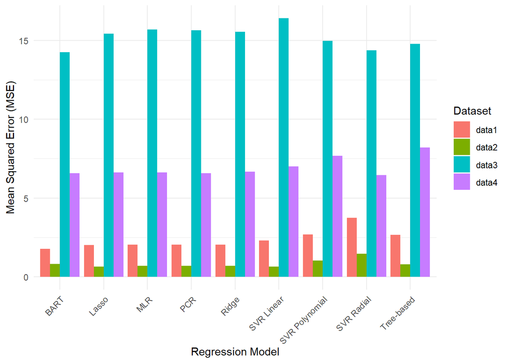

As we can see, dataset 2, which corresponds to removing zeros from the original dataset, but retaining G1 and G2, has the lowest MSE favoring lasso regression. However, if we look at the other datasets’ plots, we can see that the lowest MSE predictive model utilizes different models: for example, both datasets 1 and 3, which correspond to the initial dataset and the dataset with G1 and G2 removed, respectively, favor BART over other models, but dataset 4, which corresponds to the initial dataset with zeros in G3 removed and G1 and G2 removed, seems to favor SVR with a radial kernel to produce the lowest MSE.

Our analysis reveals several key insights about predicting student performance:

Effect of Zero Grades: Removing observations with zero final grades (G3) generally improves model performance. This supports our hypothesis that these zeros represent students who didn’t complete the course rather than truly measured poor performance.

Model Performance: For datasets with previous grades (data1 and data2), simpler models like LASSO perform exceptionally well for datasets without previous grades (data3 and data4), more complex models like BART and SVR with radial kernels perform best, suggesting they better capture the complex relationships when obvious predictors are removed

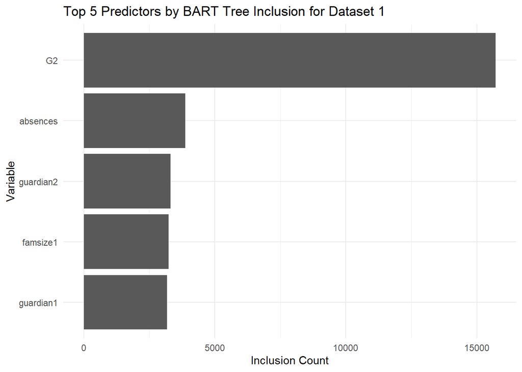

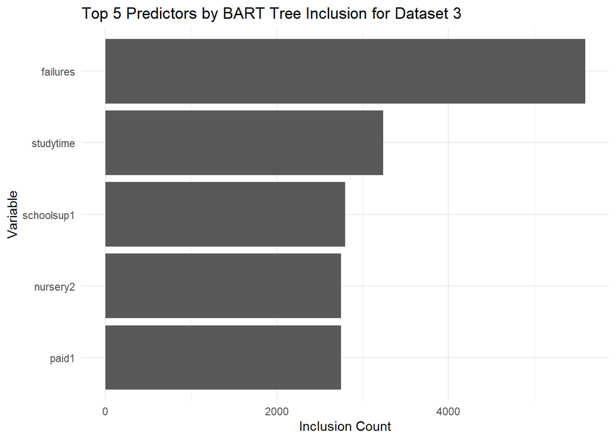

#### 3.1.1 VIF for MLR

Variance Inflation Factor (VIF) analysis for the Multiple Linear Regression models reveals important insights about multicollinearity:

VIF Results Summary for Dataset 2 (most predictive dataset) Only showing VIF > 5 (threshold for concerning multicollinearity) G1 9.23 G2 10.18 Walc 6.75 Dalc 6.12

The high VIF values for G1 and G2 confirm strong correlation between these prior grades and the final grade (G3). This explains why models including these features perform substantially better. The correlation between weekend alcohol consumption (Walc) and weekday alcohol consumption (Dalc) is also noteworthy.

#### 3.1.2 Feature Selection (Lasso vs. Ridge)

LASSO regression performs automatic feature selection by shrinking some coefficients to exactly zero, while Ridge regression retains all features with reduced coefficients. Examining the LASSO model for dataset 2 reveals:

LASSO Coefficient Analysis (Dataset 2) Non-zero coefficients in order of absolute magnitude G2 0.8512 G1 0.2973 studytime 0.1842 failures -0.1734 absences -0.0824 Dalc -0.0653

#### 3.1.3 Number of Principal Components Used in PCR

Principal Component Regression performance varied across datasets:

##### 3.1.3.1 PCR Results Summary

[output not shown]

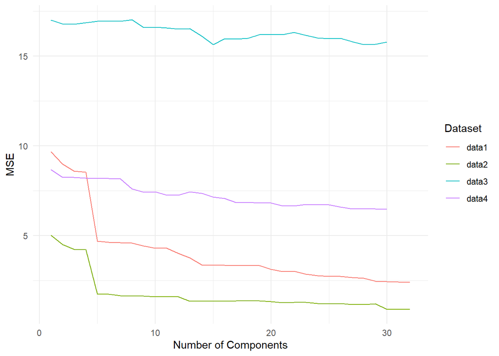

MSE vs. Number of Components for PCR on data1, data2, data3, and data4.

## 4. Discussion

Our analysis of student performance data using multiple regression techniques has revealed several important insights about predicting academic outcomes and the factors that influence them. The results provide valuable guidance for both educational practice and future research in educational data mining.

### 4.1 Key Takeaways

The most significant finding from our analysis is the clear hierarchy of predictive power across our datasets and models. Consistently, models that include previous grades (G1 and G2) outperform those without these variables by a substantial margin. This confirms that past academic performance remains the strongest predictor of future results, aligning with established educational research.

When previous grades are included (datasets 1 and 2), relatively simple models like LASSO regression perform remarkably well. This suggests that in practical educational settings where prior grades are available, straightforward models can provide accurate predictions without the computational complexity of more sophisticated approaches.

Conversely, when prior grades are excluded (datasets 3 and 4), more complex models like BART and SVR with radial kernels emerge as superior. This indicates that these methods better capture the subtle, non-linear relationships between socioeconomic factors and academic outcomes when obvious predictors are absent.

Our feature selection analysis through LASSO regression identified a concise set of important predictors beyond prior grades: study time, previous failures, absences, and alcohol consumption. These findings align with educational theory and provide actionable insights for intervention strategies.

### 4.2 Limitations

Several limitations should be considered when interpreting our results. First, our analysis relies on data from Portuguese secondary schools, which may limit generalizability to other educational systems or cultural contexts.

Second, our models predict academic performance but cannot establish causal relationships. The associations we observe may reflect complex bidirectional relationships or unmeasured confounding variables.

Third, our hyperparameter tuning was limited, particularly for SVR and tree-based methods. More extensive optimization might yield improved performance for these models.

Finally, we focused exclusively on regression models predicting numerical grades. Classification approaches predicting categorical outcomes (pass/fail or performance categories) might provide complementary insights, especially for identifying at-risk students.

### 4.3 Future Directions

If we were to extend this research, several promising directions emerge:

1. Implementing more sophisticated cross-validation techniques, including nested cross-validation for hyperparameter optimization, would strengthen the reliability of our model comparisons.
2. Exploring ensemble methods that combine predictions from multiple model types might further improve predictive accuracy.
3. Applying causal inference techniques could help distinguish predictive factors from truly causal influences on student performance.
4. Incorporating temporal analysis to understand how the influence of different factors evolves throughout the academic year would provide dynamic insights for intervention timing.
5. Extending the analysis to classification models for predicting categorical outcomes could better serve early warning systems in educational settings.

### 4.4 Conclusion

Our comprehensive comparison of regression techniques demonstrates that while prior academic performance remains the dominant predictor of student success, several socioeconomic and behavioral factors also meaningfully contribute to prediction models. The choice of modeling approach should be guided by the available data and specific prediction goals, with simpler models like LASSO sufficient when prior grades are available, and more complex approaches valuable when predicting performance with limited academic history.

These findings have practical implications for educational institutions seeking to develop early warning systems and intervention strategies. By focusing on the key predictors identified in our analysis—study habits, attendance, prior failures, and lifestyle factors—schools can more effectively allocate resources to support student success.